# RNA-seq QC and Unsupervised Analysis Report

## Overview

This report demonstrates a modular RNA-seq-style analysis pipeline implemented in R. Simulated gene expression data are generated, missingness is introduced, normalization is applied, and quality control metrics are computed prior to exploratory dimensionality reduction and clustering.

The goal is to demonstrate foundational bioinformatics data processing and unsupervised analysis workflows.

## Setup

```r
knitr::opts_chunk$set(echo = TRUE)

source("../scripts/simulate_data.R")
source("../scripts/preprocessing.R")
source("../scripts/qc_analysis.R")
source("../scripts/dim_reduction.R")
source("../scripts/run_pipeline.R")
```

# Running the Pipeline

```r
res <- run_pipeline(
  num_genes = 2000,
  num_samples = 30,
  missing_frac = 0.1,
  seed = 1,
  k = 3
)
```

# Overview of Simulated Data

Gene expression values were simulated from a log-normal distribution and 10% missingness was introduced at random.

```r
summary(res$expr_norm)
```

```
##     Sample_1        Sample_2        Sample_3        Sample_4
##  Min.   :2.616   Min.   :2.351   Min.   :2.289   Min.   :2.739
##  1st Qu.:5.118   1st Qu.:5.126   1st Qu.:5.205   1st Qu.:5.126
##  Median :5.761   Median :5.779   Median :5.838   Median :5.837
##  Mean   :5.782   Mean   :5.797   Mean   :5.853   Mean   :5.813
##  3rd Qu.:6.492   3rd Qu.:6.507   3rd Qu.:6.480   3rd Qu.:6.489
##  Max.   :9.604   Max.   :8.855   Max.   :8.715   Max.   :9.443
##  NA's   :199     NA's   :186     NA's   :196     NA's   :218
##     Sample_5        Sample_6        Sample_7        Sample_8
##  Min.   :2.487   Min.   :3.071   Min.   :2.430   Min.   :2.780
##  1st Qu.:5.203   1st Qu.:5.177   1st Qu.:5.140   1st Qu.:5.126
##  Median :5.835   Median :5.813   Median :5.807   Median :5.806
##  Mean   :5.844   Mean   :5.842   Mean   :5.827   Mean   :5.821
##  3rd Qu.:6.490   3rd Qu.:6.521   3rd Qu.:6.489   3rd Qu.:6.482
##  Max.   :9.227   Max.   :9.094   Max.   :9.548   Max.   :9.062
##  NA's   :204     NA's   :196     NA's   :198     NA's   :195
##     Sample_9       Sample_10       Sample_11       Sample_12
##  Min.   :2.193   Min.   :2.549   Min.   :2.801   Min.   :2.674
##  1st Qu.:5.116   1st Qu.:5.167   1st Qu.:5.186   1st Qu.:5.166
##  Median :5.817   Median :5.822   Median :5.877   Median :5.816
##  Mean   :5.798   Mean   :5.830   Mean   :5.845   Mean   :5.819
##  3rd Qu.:6.470   3rd Qu.:6.464   3rd Qu.:6.493   3rd Qu.:6.471
##  Max.   :9.253   Max.   :9.492   Max.   :8.967   Max.   :9.348
##  NA's   :188     NA's   :213     NA's   :218     NA's   :185
##    Sample_13       Sample_14       Sample_15       Sample_16
##  Min.   :2.693   Min.   :2.791   Min.   :2.271   Min.   :2.089
##  1st Qu.:5.129   1st Qu.:5.149   1st Qu.:5.081   1st Qu.:5.147
##  Median :5.882   Median :5.830   Median :5.773   Median :5.839
##  Mean   :5.837   Mean   :5.835   Mean   :5.787   Mean   :5.820
##  3rd Qu.:6.505   3rd Qu.:6.509   3rd Qu.:6.459   3rd Qu.:6.474
##  Max.   :8.795   Max.   :8.758   Max.   :9.452   Max.   :8.863
##  NA's   :199     NA's   :233     NA's   :199     NA's   :192
##    Sample_17       Sample_18       Sample_19       Sample_20
##  Min.   :2.458   Min.   :2.936   Min.   :2.245   Min.   :2.876
##  1st Qu.:5.118   1st Qu.:5.145   1st Qu.:5.152   1st Qu.:5.155
##  Median :5.797   Median :5.840   Median :5.863   Median :5.856
##  Mean   :5.809   Mean   :5.848   Mean   :5.831   Mean   :5.824
##  3rd Qu.:6.485   3rd Qu.:6.507   3rd Qu.:6.507   3rd Qu.:6.484
##  Max.   :9.211   Max.   :8.805   Max.   :9.677   Max.   :9.118
##  NA's   :174     NA's   :203     NA's   :208     NA's   :208
```

[output cut: 9 more lines]

```
##  Min.   :2.571   Min.   :2.571   Min.   :1.784   Min.   :2.636
##  1st Qu.:5.078   1st Qu.:5.153   1st Qu.:5.112   1st Qu.:5.192
##  Median :5.746   Median :5.823   Median :5.801   Median :5.855
##  Mean   :5.791   Mean   :5.812   Mean   :5.804   Mean   :5.838
##  3rd Qu.:6.472   3rd Qu.:6.463   3rd Qu.:6.512   3rd Qu.:6.480
##  Max.   :9.323   Max.   :9.238   Max.   :8.878   Max.   :9.258
##  NA's   :180     NA's   :182     NA's   :191     NA's   :210
##    Sample_29       Sample_30
##  Min.   :3.037   Min.   :2.412
##  1st Qu.:5.174   1st Qu.:5.151
##  Median :5.837   Median :5.828
##  Mean   :5.835   Mean   :5.815
##  3rd Qu.:6.499   3rd Qu.:6.484
##  Max.   :9.078   Max.   :9.218
##  NA's   :186     NA's   :169
```

# QC Metrics

```r
head(res$sample_qc)
```

```
##          sample_id n_genes missing_frac     mean   median        sd
## Sample_1  Sample_1    2000       0.0995 5.782368 5.760864 1.0309797
## Sample_2  Sample_2    2000       0.0930 5.796728 5.779004 1.0319042
## Sample_3  Sample_3    2000       0.0980 5.853013 5.837642 0.9755469
## Sample_4  Sample_4    2000       0.1090 5.812735 5.836666 1.0223912
## Sample_5  Sample_5    2000       0.1020 5.843654 5.834995 0.9733203
## Sample_6  Sample_6    2000       0.0980 5.842304 5.812852 0.9748562
##          detected_genes detected_frac
## Sample_1           1801        0.9005
## Sample_2           1814        0.9070
## Sample_3           1804        0.9020
## Sample_4           1782        0.8910
## Sample_5           1796        0.8980
## Sample_6           1804        0.9020
```

```r
summary(res$sample_qc$missing_frac)
```

```
##    Min. 1st Qu.  Median    Mean 3rd Qu.    Max.
## 0.08450 0.09438 0.09950 0.10000 0.10537 0.11650
```

Missingness is centered around 10%, consistent with the simulation design. Detection rates per sample are approximately 90%, suggesting uniform data quality across samples. No samples exhibit extreme missingness or markedly reduced detection rates, indicating that downstream dimensionality reduction is unlikely to be driven by technical artifacts.

# PCA Results

```r
summary(res$pca)
```

```
## Importance of components:
##                            PC1     PC2     PC3     PC4     PC5     PC6     PC7
## Standard deviation     9.24389 9.08068 8.98531 8.96826 8.88191 8.77913 8.71614
## Proportion of Variance 0.04272 0.04123 0.04037 0.04021 0.03944 0.03854 0.03799
## Cumulative Proportion  0.04272 0.08395 0.12432 0.16454 0.20398 0.24252 0.28050
##                            PC8     PC9    PC10   PC11    PC12    PC13    PC14
## Standard deviation     8.62326 8.60889 8.51679 8.4617 8.40606 8.39268 8.30913
## Proportion of Variance 0.03718 0.03706 0.03627 0.0358 0.03533 0.03522 0.03452
## Cumulative Proportion  0.31768 0.35474 0.39101 0.4268 0.46214 0.49736 0.53188
##                           PC15    PC16   PC17   PC18    PC19    PC20    PC21
## Standard deviation     8.27810 8.23778 8.1731 8.1613 8.11831 8.02254 8.01509
## Proportion of Variance 0.03426 0.03393 0.0334 0.0333 0.03295 0.03218 0.03212
## Cumulative Proportion  0.56614 0.60007 0.6335 0.6668 0.69973 0.73191 0.76403
##                           PC22    PC23    PC24    PC25    PC26    PC27    PC28
## Standard deviation     7.94083 7.84077 7.76571 7.75756 7.68842 7.59201 7.46154
## Proportion of Variance 0.03153 0.03074 0.03015 0.03009 0.02956 0.02882 0.02784
## Cumulative Proportion  0.79556 0.82630 0.85645 0.88654 0.91610 0.94492 0.97275
##                           PC29      PC30
## Standard deviation     7.38202 1.457e-14
## Proportion of Variance 0.02725 0.000e+00
## Cumulative Proportion  1.00000 1.000e+00
```

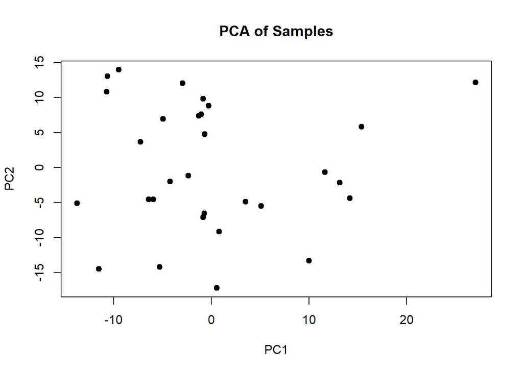

```r
plot_pca(res$pca)
```

# k-means Clustering

```r
res$kmeans$cluster
```

```
##  Sample_1  Sample_2  Sample_3  Sample_4  Sample_5  Sample_6  Sample_7  Sample_8
##         3         1         3         2         3         2         2         3
##  Sample_9 Sample_10 Sample_11 Sample_12 Sample_13 Sample_14 Sample_15 Sample_16
##         1         3         3         3         3         3         2         3
## Sample_17 Sample_18 Sample_19 Sample_20 Sample_21 Sample_22 Sample_23 Sample_24
##         2         1         2         3         3         3         1         3
## Sample_25 Sample_26 Sample_27 Sample_28 Sample_29 Sample_30
##         1         2         2         2         2         2
```

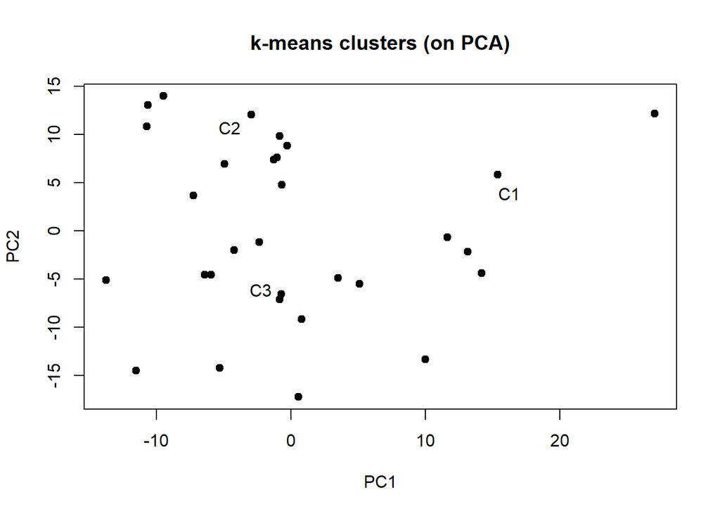

```r
plot_kmeans_on_pca(res$pca, res$kmeans)
```

k-means clustering partitions samples into three groups based on similarity in principal component space. Given the simulated nature of the data without embedded biological structure, clusters reflect random structure rather than meaningful biological grouping.

## Potential Next Steps

- Model biologically realistic dropout by increasing missingness probability for low-expression genes.
- Implement additional outlier detection metrics, such as sample correlation thresholds or variance-based filtering.
- Incorporate gene filtering prior to PCA to remove low-detection genes.
- Compare clustering performed directly on normalized data versus PCA-reduced space.